# Machine Learning I

## 11/07/2024

print view  
notebook

## What is machine learning?

*Machine learning is a subfield of computer science that evolved from the study of pattern recognition and computational learning theory in artificial intelligence. Machine learning explores the study and construction of algorithms that can learn from and make predictions on data.* --Wikipedia

Creating useful and/or predictive computational models from data

- Unsupervised learning: features
- Supervised learning: features + labels

# Unsupervised Learning

Construct a model from unlabeled data. That is, discover an underlying structure in the data.

We have already looked at

- Clustering
- Principal Components Analysis (PCA)
- t-SNE
- UMAP
- Expectation maximization

## Expectation Maximization

**Traditional use: Approach to find a parametric model for data, when the model not only has parameters but also hidden (latent) variables**

**Let us consider a Gaussian mixture model**

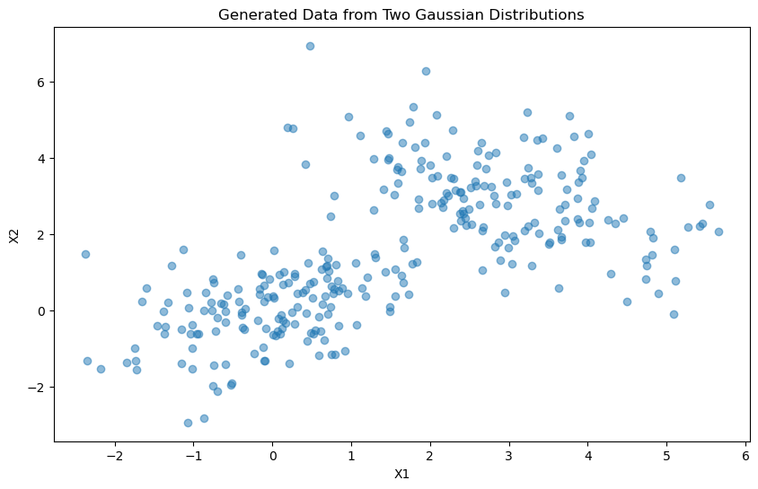

```python
import numpy as np
import matplotlib.pyplot as plt
from scipy.stats import multivariate_normal

# Step 1: Generate synthetic data
np.random.seed(42)
n_samples = 300

# Generate samples from two Gaussian distributions
mean1, cov1 = [0, 0], [[1, 0.5], [0.5, 1]]
mean2, cov2 = [3, 3], [[1.5, -0.7], [-0.7, 1.5]]
samples1 = np.random.multivariate_normal(mean1, cov1, n_samples // 2)
samples2 = np.random.multivariate_normal(mean2, cov2, n_samples // 2)
X = np.vstack((samples1, samples2))

# Visualize the generated data
plt.figure(figsize=(10, 6))
plt.scatter(X[:, 0], X[:, 1], alpha=0.5)
plt.title("Generated Data from Two Gaussian Distributions")
plt.xlabel("X1")
plt.ylabel("X2")
plt.show()
```

**This model can be defined as**

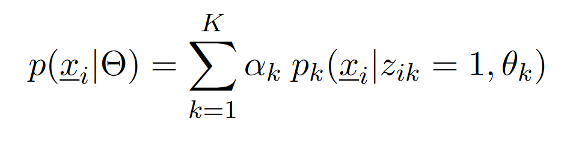

**where**

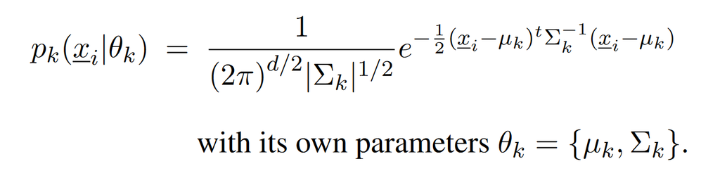

## Basic steps of EM algorithm

**Intuition**

- EM algorithm is an iterative algorithm that starts from some initial estimate of the parameter set $\theta$, or the membership weight $\alpha_{k}$ .
- This can be random initialization or a warm start.
- It then proceed to iteratively update the parameter estimates until convergence is detected. Each iteration consists of an E-step and an M-step.
- *E-step*: Compute the expected value of the “membership weight” of data point $\underline{x}_{i}$ in component $k$ given the data and current estimate of the parameter value ($\theta$)
- *M-step*: Compute the new parameter values ($\theta$ and $\alpha_{k}$) given the membership weights that maximize the expected log-likelihood given by $\alpha_{k}$.

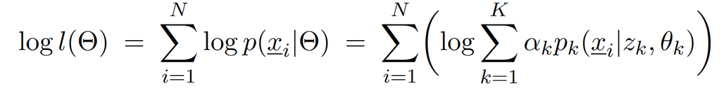

- Iterate till convergence or maximum number of iterations.

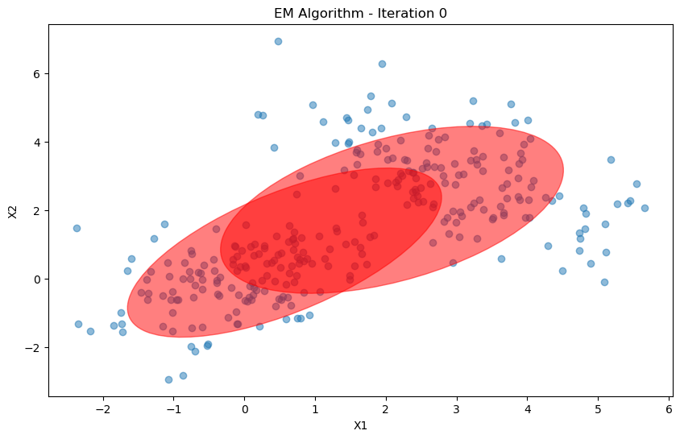

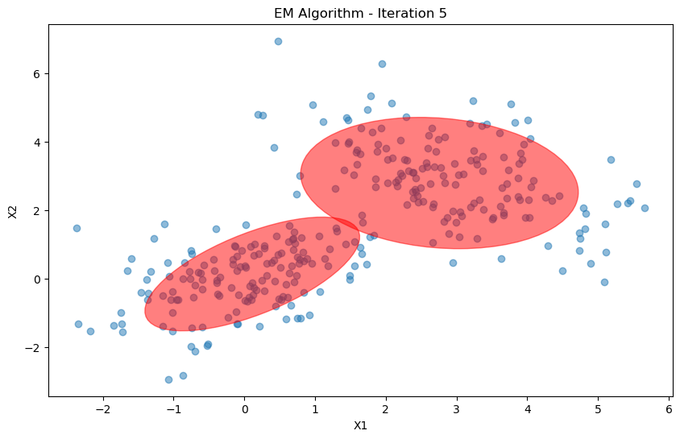

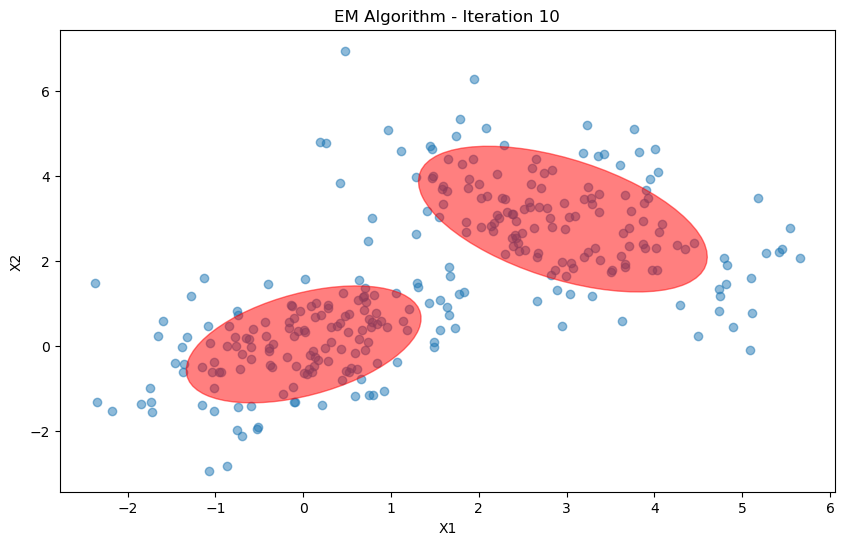

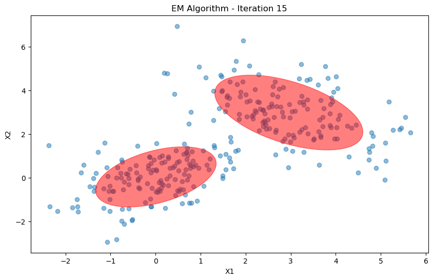

```
Final weights: [0.50089109 0.49910891]
Final means: [[2.9581675  2.97932781]
 [0.00640229 0.03442106]]
Final covariances: [array([[ 1.3520505 , -0.73150302],
       [-0.73150302,  1.46582797]]), array([[0.89682937, 0.41145   ],
       [0.41145   , 0.94723559]])]
```

```python
# Step 2: Implement EM algorithm for GMM
def em_gmm(X, n_components, n_iterations):
    n_samples, n_features = X.shape

    # Initialize parameters
    weights = np.ones(n_components) / n_components
    means = X[np.random.choice(n_samples, n_components, replace=False)]
    covs = [np.eye(n_features) for _ in range(n_components)]

    def plot_current_state(X, weights, means, covs, iteration):
        plt.figure(figsize=(10, 6))
        plt.scatter(X[:, 0], X[:, 1], alpha=0.5)
        for i, (weight, mean, cov) in enumerate(zip(weights, means, covs)):
            v, w = np.linalg.eigh(cov)
            v = 2. * np.sqrt(2.) * np.sqrt(v)
            u = w[0] / np.linalg.norm(w[0])
            angle = np.arctan(u[1] / u[0])
            angle = 180. * angle / np.pi  # convert to degrees
            ell = plt.matplotlib.patches.Ellipse(mean, v[0], v[1], angle=angle, color='r', alpha=0.5)
            ell.set_clip_box(plt.gca().bbox)
            plt.gca().add_artist(ell)
        plt.title(f"EM Algorithm - Iteration {iteration}")
        plt.xlabel("X1")
        plt.ylabel("X2")
        plt.show()

    for iteration in range(n_iterations):
        # E-step: Compute membership probabilities
        resp = np.zeros((n_samples, n_components))
        for k in range(n_components):
            resp[:, k] = weights[k] * multivariate_normal.pdf(X, mean=means[k], cov=covs[k])
        resp /= resp.sum(axis=1, keepdims=True)

        # M-step: Update parameters
        N_k = resp.sum(axis=0)
        for k in range(n_components):
            means[k] = (resp[:, k][:, np.newaxis] * X).sum(axis=0) / N_k[k]
            diff = X - means[k]
            covs[k] = np.dot(resp[:, k] * diff.T, diff) / N_k[k]
        weights = N_k / n_samples

        # Visualize current state
        if iteration % 5 == 0:
            plot_current_state(X, weights, means, covs, iteration)

    return weights, means, covs

# Run EM algorithm
n_components = 2
n_iterations = 20
final_weights, final_means, final_covs = em_gmm(X, n_components, n_iterations)

# Print final parameters
print("Final weights:", final_weights)
print("Final means:", final_means)
print("Final covariances:", final_covs)
```

**So let us look at an example**

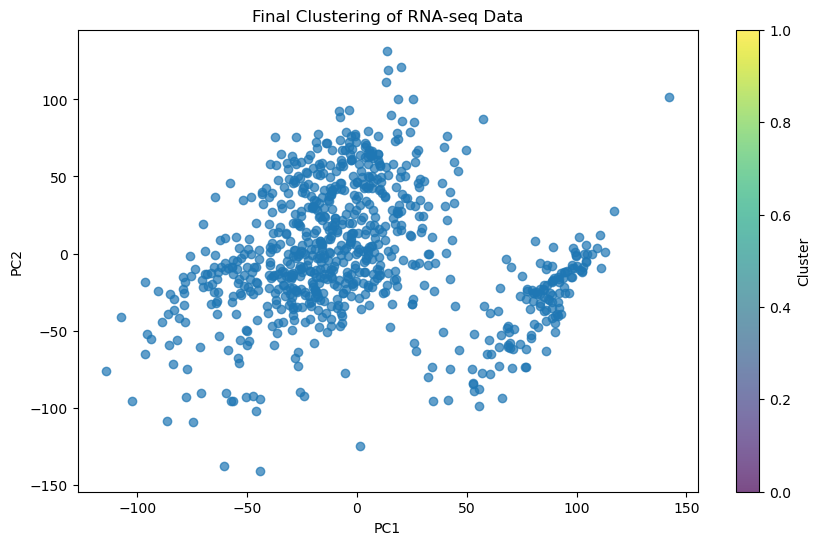

```python
import numpy as np
import pandas as pd
import matplotlib.pyplot as plt
from sklearn.preprocessing import StandardScaler, LabelEncoder
from sklearn.decomposition import PCA

# Step 1: Load and preprocess RNA-seq data
url = "https://archive.ics.uci.edu/ml/machine-learning-databases/00401/TCGA-PANCAN-HiSeq-801x20531.tar.gz"
data = pd.read_csv(url, compression='gzip', sep=',', header=0,low_memory=False)

# Identify the class column (assuming it's the first column)
class_col = data.columns[0]

# Separate features and labels
X = data.iloc[:, 1:]  # All columns except the first one
y = data[class_col]

# Encode the labels
le = LabelEncoder()
y_encoded = le.fit_transform(y)

# Function to convert to float or NaN
def to_float(x):
    try:
        return float(x)
    except:
        return np.nan

# Convert features to float, replacing any non-convertible values with NaN
X = X.map(to_float)

#Remove the first column due to its awkward behaviour
X = X.iloc[:,1:X.shape[1]]

# Remove any rows with NaN values
X = X.dropna()
y_encoded = y_encoded[X.index]

# Standardize the features
scaler = StandardScaler()
X_scaled = scaler.fit_transform(X)

# Step 2: Apply PCA for dimensionality reduction
pca = PCA(n_components=2)
X_pca = pca.fit_transform(X_scaled)
plt.figure(figsize=(10, 6))
scatter = plt.scatter(X_pca[:, 0], X_pca[:, 1], alpha=0.7)
plt.title("Final Clustering of RNA-seq Data")
plt.xlabel("PC1")
plt.ylabel("PC2")
plt.colorbar(scatter, label="Cluster")
plt.show()
```

**This looks like a Gaussian mixture model**

So lets give GMM a try based on random initialization.

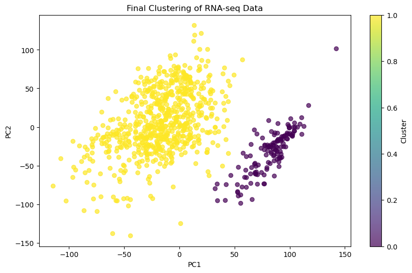

```python
from sklearn.mixture import GaussianMixture
# Step 3: Apply EM algorithm using GaussianMixture
n_components = 2; #len(np.unique(y_encoded))  # Number of unique cancer types
gmm = GaussianMixture(n_components=n_components,
                          random_state=1, init_params='random',max_iter=100)
gmm.fit(X_pca)
#plot_em_step(X_pca, gmm, i+1)

# Final clustering results
labels2 = gmm.predict(X_pca)

# Visualize final clustering
plt.figure(figsize=(10, 6))
scatter = plt.scatter(X_pca[:, 0], X_pca[:, 1], c=labels2, cmap='viridis', alpha=0.7)
plt.title("Final Clustering of RNA-seq Data")
plt.xlabel("PC1")
plt.ylabel("PC2")
plt.colorbar(scatter, label="Cluster")
plt.show()
```

**This worked quite well. However, if our random initialization is different... what happens then...**

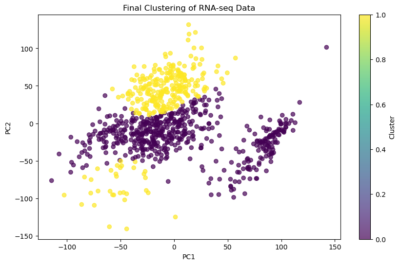

```python
# Step 3: Apply EM algorithm using GaussianMixture
n_components = 2; #len(np.unique(y_encoded))  # Number of unique cancer types
gmm = GaussianMixture(n_components=n_components,
                          random_state=30, init_params='random',max_iter=200)
gmm.fit(X_pca)
#plot_em_step(X_pca, gmm, i+1)

# Final clustering results
labels2 = gmm.predict(X_pca)

# Visualize final clustering
plt.figure(figsize=(10, 6))
scatter = plt.scatter(X_pca[:, 0], X_pca[:, 1], c=labels2, cmap='viridis', alpha=0.7)
plt.title("Final Clustering of RNA-seq Data")
plt.xlabel("PC1")
plt.ylabel("PC2")
plt.colorbar(scatter, label="Cluster")
plt.show()
```

**This is not good. It shows that EM is a greedy algorithm that can get stuck in a local minima**

**So what if do a warm start, say using k-means**

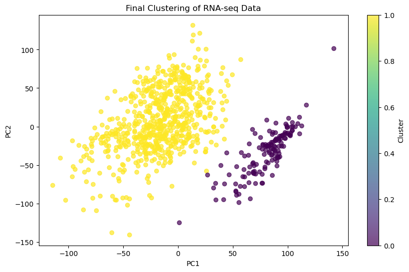

```python
import os
os.environ['OMP_NUM_THREADS'] = '4';
# Step 3: Apply EM algorithm using GaussianMixture
n_components = 2; #len(np.unique(y_encoded))  # Number of unique cancer types
gmm = GaussianMixture(n_components=n_components,
                          init_params='kmeans',max_iter=1)
gmm.fit(X_pca)
#plot_em_step(X_pca, gmm, i+1)

# Final clustering results
labels2 = gmm.predict(X_pca)

# Visualize final clustering
plt.figure(figsize=(10, 6))
scatter = plt.scatter(X_pca[:, 0], X_pca[:, 1], c=labels2, cmap='viridis', alpha=0.7)
plt.title("Final Clustering of RNA-seq Data")
plt.xlabel("PC1")
plt.ylabel("PC2")
plt.colorbar(scatter, label="Cluster")
plt.show()
```

**It worked! Interestingly with only one iteration... Why?**

# Supervised Learning

Create a model from labeled data. The data consists of a set of *examples* where each example has a number of features *X* and a label *y*.

Our assumption is that the label is a function of the features: $$y = f(X)$$
And our goal is to determine what f is. We want a model/estimator/classifier that accurately predicts *y* given an *X*.

$X \rightarrow$

Model

$ \rightarrow y$

# Labels

There are two main types of supervised learning depending on the type of label.

## Classification

The label is one of a limited number of classes. Most commonly it is a binary label.

- Will it rain tomorrow?
- Is the protein overexpressed?
- Do the cells die?

## Regression

The label is a continuous value.

- How much precipitation will there be tomorrow?
- What is the expression level of the protein?
- What percent of the cells died?

# Features

The features, *X*, are what make each example distinct. Ideally they contain enough information to predict *y*. The choice of features is critical and problem-specific.

There are three main three main types:

- Binary - zero or one
- Nominal - one of a limited number of values
  - low, medium, high
  - nucleus, vacuole, cytoplasm
- Numerical

Not all classifiers can handle all three types, but we can inter-convert.

# Example

Let's use chemical fingerprints as features

```python
import wget
wget.download("http://mscbio2025.csb.pitt.edu/files/er.smi")
```

```
100% [..............................................................................] 20022 / 20022
```

```
'er.smi'
```

```python
from openbabel import pybel
yvals = []
fps = []
for mol in pybel.readfile('smi','er.smi'):
    yvals.append(float(mol.title))
    fpbits = mol.calcfp().bits
    fp = np.zeros(1024)
    fp[fpbits] = 1
    fps.append(fp)

X = np.array(fps)
y = np.array(yvals)
```

```python
print(X.shape)
```

```
(387, 1024)
```

```python
X[0]
```

```
array([0., 0., 0., ..., 0., 0., 0.])
```

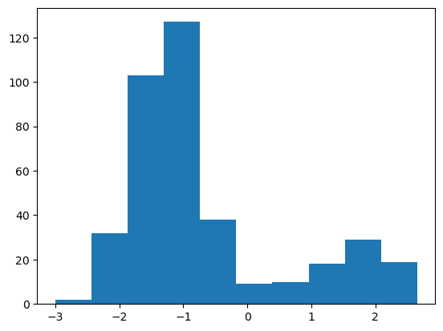

```python
plt.hist(y);
```

# Linear Model

One of the simplest models is a linear regression, where the goal is to find weights *w* to minimize: $$\sum(Xw - y)^2$$

```python
from sklearn import linear_model
model = linear_model.LinearRegression() # create the model
model.fit(X,y) # fit the model to the data
p = model.predict(X) # make predictions with the model
```

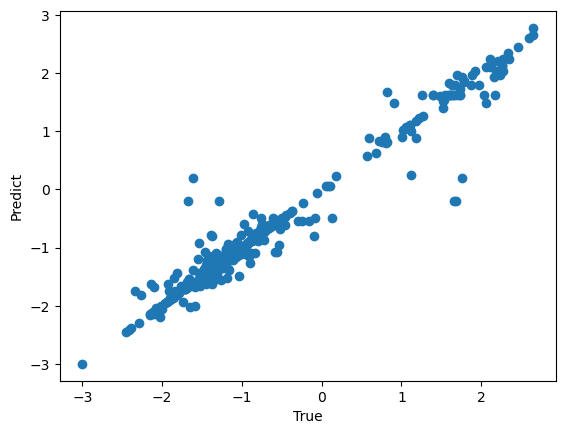

```python
plt.scatter(y,p); plt.xlabel('True'); plt.ylabel('Predict');
```

**Let's reframe this is a classification problem for illustrative purposes...**

```python
ylabel = y > -1
plabel = p > -1
```

# Evaluating Predictions

There are a number of ways to evaluate how good a prediction is.

- *TP* true positive, a correctly predicted positive example
- *TN* true negatie, a correctly predicted negative example
- *FP* false positive, a negative example incorrectly predicted as positive
- *FN* false negative, a positive example incorrectly predicted as negative
- *P* total number of positives (*TP* + *FN*)
- *N* total number of negatives (*TN* + *FP*)

Accuracy: $\frac{TP+TN}{P+N}$

```python
from sklearn.metrics import * #pull in accuracy score, amount other things
accuracy_score(ylabel, plabel)
```

```
0.9431524547803618
```

# Confusion matrix

The confusion matrix compares the predicted class to the actual class.

```python
print(confusion_matrix(ylabel,plabel))
```

```
[[200  12]
 [ 10 165]]
```

```python
print(np.array([['TN', 'FP'],['FN','TP']]))
```

```
[['TN' 'FP']
 ['FN' 'TP']]
```

# Other measures

Precision. Of those predicted true, how may are accurate? $\frac{TP}{TP+FP}$

Recall (true positive rate). How many of the true examples were retrieved? $\frac{TP}{P}$

```python
print(classification_report(ylabel,plabel))
```

```
              precision    recall  f1-score   support

       False       0.95      0.94      0.95       212
        True       0.93      0.94      0.94       175

    accuracy                           0.94       387
   macro avg       0.94      0.94      0.94       387
weighted avg       0.94      0.94      0.94       387
```

# ROC Curves

The previous metrics work on classification results (yes or no). Many models are capable of producing scores or probabilities (recall we had to threshold our results). The classification performance then depends on what score threshold is chosen to distinguish the two classes.

ROC curves plot the false positive rate and true positive rate as this treshold is changed.

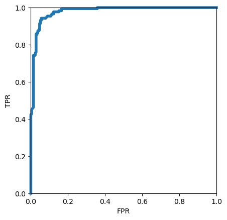

```python
fpr, tpr, thresholds = roc_curve(ylabel, p)  #not using rounded values
plt.plot(fpr,tpr,linewidth=4,clip_on=False)
plt.xlabel("FPR"); plt.ylabel("TPR")
plt.gca().set_aspect('equal')
plt.ylim(0,1); plt.xlim(0,1); plt.show()
```

# AUC

The area under the ROC curve (AUC) has a statistical meaning. It is equal to the probability that the classifier will rank a randomly chosen positive example higher than a randomly chosen negative example.

An AUC of one is perfect prediction.

An AUC of 0.5 is the same as random.

```
0.5256469002695419
```

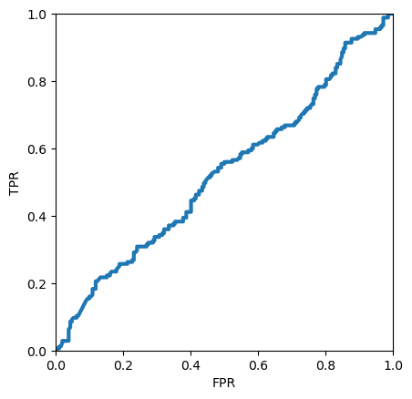

```python
np.random.shuffle(p)
fpr, tpr, thresholds = roc_curve(ylabel, p)
plt.plot(fpr,tpr,linewidth=3); plt.xlabel("FPR"); plt.ylabel("TPR"); plt.ylim(0,1); plt.xlim(0,1)
plt.gca().set_aspect('equal')

print(roc_auc_score(ylabel,p))
```